# Playstore Apps (Classification Problem)

07-04-2024

## Introduction

Team Members:

Andreas Papadopoulos

Constantinos Constantinou

Foivos Lympouras

Iosif Pintirishis

In today’s fast-moving smartphone world, Android is a key player, with over 2 billion people using it every month. This success comes from not just its easy-to-use design and high-tech features, but also from the huge number of apps available, both free and paid. Our university project is all about understanding how popular an Android app might become. We plan to use machine learning to predict how many times an app will be downloaded based on different factors.

```r
rm(list = ls())
```

## Functions

```r
# Convert the size to number
convert_size_to_bytes <- function(size) {
  num <- as.numeric(sub("[^0-9.]", "", size))
  unit <- substr(size, nchar(size), nchar(size))

  if (!is.na(num)) {
    if (unit == "k") {
      return(num/1024)
    } else if (unit == "M") {
      return(num)  # Megabytes to bytes
    } else {
      # If there is no k or M, assume the number is already in bytes
      return(num / (1024^2))
    }
  } else {
    # Return NA if the numeric part couldn't be extracted
    return(NA)
  }
}
```

## Load packages

```r
list.of.packages <- c("ggplot2","DescTools", "nortest", "moments", "dplyr","corrplot","mice","factoextra","patchwork", "class","fastDummies", "randomForest", "MASS", "naivebayes", "glmnet")
new.packages <- list.of.packages[!(list.of.packages %in% installed.packages()[, "Package"])]
# Install them in case they are not already
if (length(new.packages)) install.packages(new.packages)
# Load packages
invisible(lapply(list.of.packages, library, character.only = TRUE))
```

```
## Thank you for using fastDummies!
```

```
## To acknowledge our work, please cite the package:
```

```
## Kaplan, J. & Schlegel, B. (2023). fastDummies: Fast Creation of Dummy (Binary) Columns and Rows from Categorical Variables. Version 1.7.1. URL: https://github.com/jacobkap/fastDummies, https://jacobkap.github.io/fastDummies/.
```

```
## For more information please visit:
```

```
## https://majkamichal.github.io/naivebayes/
```

## Import data

We found our dataset in a machine hack’s competition and below we you can find the link for the competition. [Playstore Dataset](https://machinehack.com/hackathons/playstore_app_downloads_prediction_weekend_hackathon_16/overview?fbclid=IwAR2AawYkaJ2RFt73R9nUGk7zLDV-rTqfih883OoSStjd0z5yeUIH_V4EBY8)

```r
# Import data
playstore <- read.csv("Train.csv")

names(playstore)
```

```
##  [1] "Offered_By"          "Category"            "Rating"
##  [4] "Reviews"             "Size"                "Price"
##  [7] "Content_Rating"      "Last_Updated_On"     "Release_Version"
## [10] "OS_Version_Required" "Downloads"
```

```r
head(playstore)
```

```
##    Offered_By            Category Rating Reviews               Size    Price
## 1 ps_id-24654             Finance   4.18    1481 Varies with device     Free
## 2 ps_id-35329     Music And Audio   4.81     302                10M     Free
## 3 ps_id-11044         Game Casual   4.27     374                27M     Free
## 4 ps_id-36068            Business   4.03  122058 Varies with device     Free
## 5 ps_id-35831             Medical   4.60     358 Varies with device 297.5742
## 6 ps_id-17918 Books And Reference   4.80      40               2.3M     Free
##   Content_Rating Last_Updated_On    Release_Version OS_Version_Required
## 1       Everyone     May 05 2020 Varies with device  Varies with device
## 2       Everyone     Mar 26 2020             3.9.18          4.1 and up
## 3       Everyone     May 01 2020             1.10.1          4.1 and up
## 4           Teen     May 02 2020 Varies with device  Varies with device
## 5       Everyone     Nov 29 2018 Varies with device  Varies with device
## 6       Everyone     Feb 05 2019                  3          4.1 and up
##     Downloads
## 1    100,000+
## 2      5,000+
## 3     10,000+
## 4 10,000,000+
## 5      5,000+
## 6     10,000+
```

```r
nrow(playstore)
```

```
## [1] 16516
```

Attributes description:

Offered_By: The publisher/Organization/Company that develops the application

Category: The category/Genre of the application

Rating: The total ratings received from consumers

Reviews: The total reviews received from consumers

Size: The size of the application with unit

Price: The total price of the application or cost of the in-app purchases

Content_Rating: The content rating for the application

Last_Updated_On: The date at which the application was last updated

Release_Version: The version of the application that is currently being served

OS_Version_Required: The minimum Android OS version required to run the application

Downloads: The approximated range of downloads for the application

## Data pre-processing

First, we will print a summary of all records of our dataset with the structure. Also, we will check if we have any missing values in our dataset.

```r
summary(playstore)
```

```
##   Offered_By          Category             Rating        Reviews
##  Length:16516       Length:16516       Min.   :1.00   Min.   :       1
##  Class :character   Class :character   1st Qu.:4.09   1st Qu.:     147
##  Mode  :character   Mode  :character   Median :4.36   Median :    1890
##                                        Mean   :4.26   Mean   :  193197
##                                        3rd Qu.:4.58   3rd Qu.:   22669
##                                        Max.   :5.00   Max.   :85766433
##      Size              Price           Content_Rating     Last_Updated_On
##  Length:16516       Length:16516       Length:16516       Length:16516
##  Class :character   Class :character   Class :character   Class :character
##  Mode  :character   Mode  :character   Mode  :character   Mode  :character
##
##
##
##  Release_Version    OS_Version_Required  Downloads
##  Length:16516       Length:16516        Length:16516
##  Class :character   Class :character    Class :character
##  Mode  :character   Mode  :character    Mode  :character
##
##
##
```

```r
str(playstore) # structure of the dataset
```

```
## 'data.frame':    16516 obs. of  11 variables:
##  $ Offered_By         : chr  "ps_id-24654" "ps_id-35329" "ps_id-11044" "ps_id-36068" ...
##  $ Category           : chr  "Finance" "Music And Audio" "Game Casual" "Business" ...
##  $ Rating             : num  4.18 4.81 4.27 4.03 4.6 4.8 4.6 4.62 3.2 4.1 ...
##  $ Reviews            : int  1481 302 374 122058 358 40 1992 37975 191 349503 ...
##  $ Size               : chr  "Varies with device" "10M" "27M" "Varies with device" ...
##  $ Price              : chr  "Free" "Free" "Free" "Free" ...
##  $ Content_Rating     : chr  "Everyone" "Everyone" "Everyone" "Teen" ...
##  $ Last_Updated_On    : chr  "May 05 2020" "Mar 26 2020" "May 01 2020" "May 02 2020" ...
##  $ Release_Version    : chr  "Varies with device" "3.9.18" "1.10.1" "Varies with device" ...
##  $ OS_Version_Required: chr  "Varies with device" "4.1 and up" "4.1 and up" "Varies with device" ...
##  $ Downloads          : chr  "100,000+" "5,000+" "10,000+" "10,000,000+" ...
```

```r
# check for missing values
sum(is.na(playstore))
```

```
## [1] 0
```

```r
# we don't have any missing values
```

There aren’t any missing values in our dataset.

Release_Version:

```r
#unique(playstore$Release_Version)
#table(playstore$Release_Version)
length(unique(playstore$Release_Version))
```

```
## [1] 4190
```

The unique values of this variable are 4190.

```r
frequency_table <- table(playstore$Release_Version)
names(frequency_table)[which.max(frequency_table)]
```

```
## [1] "Varies with device"
```

```r
names(frequency_table)[which.min(frequency_table)]
```

```
## [1] ":1.38.3+1"
```

```r
sum(playstore$Release_Version == "Varies with device")/nrow(playstore)
```

```
## [1] 0.09312182
```

We found about the most frequent value which is “Varies with device” and the less frequent which is “:1.38.3+1”.

We have 9.3% “Varies with device”, which is less than 10%, so we decide to keep that feature and replace those values with the median.

Release version Imputation: Convert major version numbers into numeric format, and stores them in a new column named Major_Version within the same playstore dataframe.

```r
train_size <- floor(0.8 * nrow(playstore))

set.seed(48)

# a vector of row indices for the training set
train_indices <- sample(seq_len(nrow(playstore)), size = train_size)
```

We split the data of the playstore into 80% train set and 20% for test set.

```r
playstore$Major_Version <- as.numeric(gsub("([0-9]+).*", "\\1", playstore$Release_Version))
# replace non-numeric values and "Varies with device" with NA
playstore$Major_Version[!grepl("^[0-9]+", playstore$Release_Version)] <- NA

# compute the median of the major column we create above
median_version_train_set <- median(playstore$Major_Version[train_indices], na.rm = TRUE)

# change the NA values with the median
playstore$Major_Version[is.na(playstore$Major_Version)] <- median_version_train_set
head(playstore$Major_Version)
```

```
## [1] 2 3 1 2 2 3
```

OS_Version_Required : Create a barplot of the frequency of OS_version_required’s values.

```r
unique(playstore$OS_Version_Required)
```

```
##  [1] "Varies with device" "4.1 and up"         "5.0 and up"
##  [4] "4.4 and up"         "4.0 and up"         "2.3.3 and up"
##  [7] "4.0.3 and up"       "4.2 and up"         "2.3 and up"
## [10] "4.3 and up"         "3.0 and up"         "2.2 and up"
## [13] "6.0 and up"         "3.1 and up"         "4.4w and up"
## [16] "5.1 and up"         "2.1 and up"         "1.5 and up"
## [19] "1.6 and up"         "8.0 and up"         "7.0 and up"
## [22] "3.2 and up"         "7.1 and up"         "1.1 and up"
## [25] "2.0 and up"         "2.0.1 and up"       "1.0 and up"
```

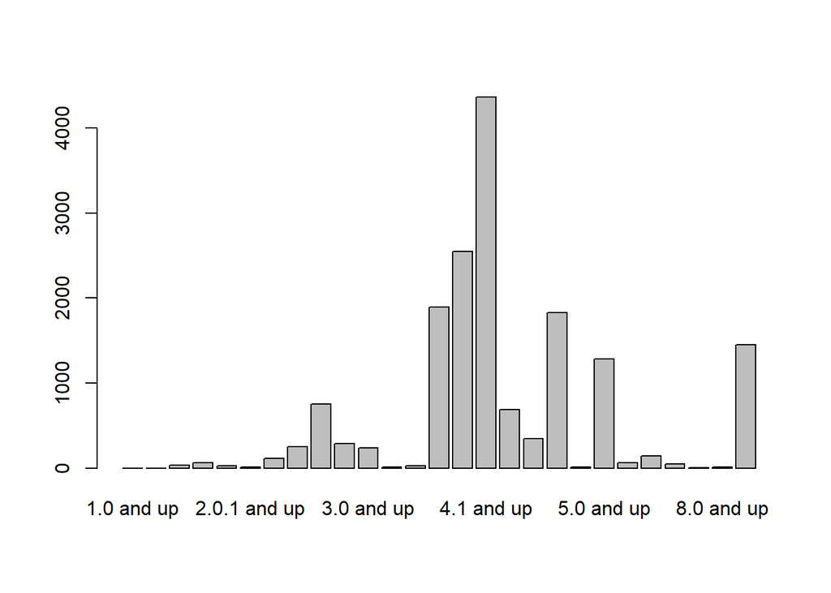

```r
frequency_table <- table(playstore$OS_Version_Required)
barplot(frequency_table)
```

Most of the values are around “4.1 and up” but also there are around 1500 values at the right corner.

```r
names(frequency_table)[which.max(frequency_table)]
```

```
## [1] "4.1 and up"
```

```r
names(frequency_table)[which.min(frequency_table)]
```

```
## [1] "1.0 and up"
```

```r
sum(playstore$OS_Version_Required== "Varies with device")/nrow(playstore)
```

```
## [1] 0.0878542
```

We have 8.8% “Varies with device”,which is less than 10%, so we decide to keep that feature and replace those values with the median.

OS Version required Imputation: Convert it to numeric format and stores them in a new column.

```r
#keep only numeric characters using gsub and then transform to numeric column
playstore$OS_Version_Numeric <- as.numeric(gsub("^([0-9]+\\.[0-9]+).*", "\\1", playstore$OS_Version_Required))
```

Replace the value “Varies with device” and the values which are not numeric with NA. Then, we calculate the median of the column we create above excluding the NAs values. Finally, change the NA values with the median.

```r
#Replaces non-numeric OS version entries in 'playstore$OS_Version_Required' with NA
playstore$OS_Version_Numeric[!grepl("^[0-9]+\\.[0-9]+", playstore$OS_Version_Required)] <- NA

#Calculates the median value of the numeric OS version, omitting NA values.
median_version <- median(playstore$OS_Version_Numeric, na.rm = TRUE)
median_version
```

```
## [1] 4.1
```

```r
#Imputes NA values in 'playstore$OS_Version_Numeric' with the median OS version number.
playstore$OS_Version_Numeric[is.na(playstore$OS_Version_Numeric)] <- median_version

head(playstore$OS_Version_Numeric)
```

```
## [1] 4.1 4.1 4.1 4.1 4.1 4.1
```

## Exploratory Data Analysis (EDA)

#### Rating

Firstly, we compute some statistics about the column `Rating`.

```r
#Measures of Central Tendency
summary(playstore$Rating)
```

```
##    Min. 1st Qu.  Median    Mean 3rd Qu.    Max.
##    1.00    4.09    4.36    4.26    4.58    5.00
```

```r
Mode(playstore$Rating)
```

```
## [1] 4.4
## attr(,"freq")
## [1] 608
```

```r
#Measures of variability
var(playstore$Rating)
```

```
## [1] 0.2489694
```

```r
sd(playstore$Rating)
```

```
## [1] 0.4989684
```

```r
IQR(playstore$Rating)
```

```
## [1] 0.49
```

```r
MeanAD(playstore$Rating)
```

```
## [1] 0.3509381
```

```r
kurtosis(playstore$Rating)
```

```
## [1] 9.655183
```

```r
skewness(playstore$Rating)
```

```
## [1] -1.968341
```

```r
sum(is.na(playstore$Rating))
```

```
## [1] 0
```

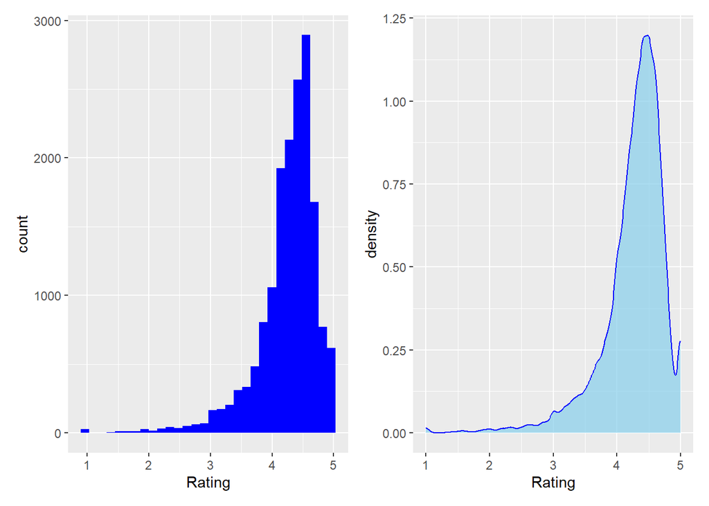

```r
#Histogram
par(mfrow=c(1,2))
h1 = ggplot(playstore, aes(x = Rating)) +
  geom_histogram(fill = "blue") + labs(x="Rating" )

h2 = ggplot(playstore, aes(x = Rating)) +
  geom_density(fill = "skyblue", color = "blue", alpha = 0.7) +
  labs(x="Rating")
h1 + h2
```

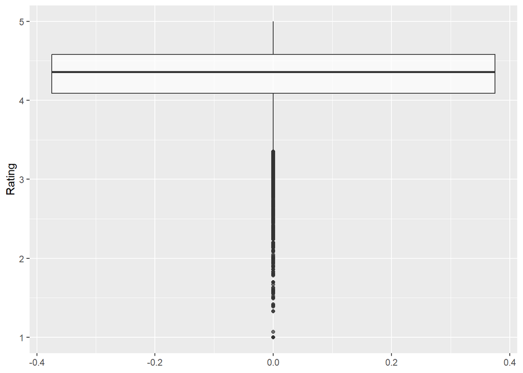

```r
#Boxplot
ggplot(playstore, aes(y = Rating)) +
  geom_boxplot( alpha = 0.7)
```

#### Reviews

Statistics for the column `Reviews`

```r
#Measures of Central Tendency
summary(playstore$Reviews)
```

```
##     Min.  1st Qu.   Median     Mean  3rd Qu.     Max.
##        1      147     1890   193197    22669 85766433
```

```r
Mode(playstore$Reviews)
```

```
## [1] 1
## attr(,"freq")
## [1] 175
```

```r
#Measures of variability
var(playstore$Reviews)
```

```
## [1] 3.817512e+12
```

```r
sd(playstore$Reviews)
```

```
## [1] 1953846
```

```r
IQR(playstore$Reviews)
```

```
## [1] 22522.25
```

```r
MeanAD(playstore$Reviews)
```

```
## [1] 324867.4
```

```r
kurtosis(playstore$Reviews)
```

```
## [1] 1020.654
```

```r
skewness(playstore$Reviews)
```

```
## [1] 28.92727
```

```r
sum(is.na(playstore$Reviews))
```

```
## [1] 0
```

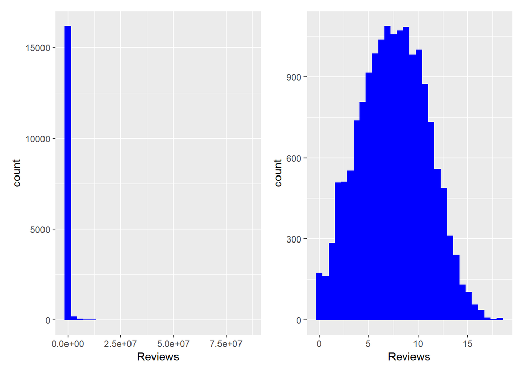

```r
#Histogram
h1 <- ggplot(playstore, aes(x = Reviews)) +
  geom_histogram(fill = "blue") + labs(x="Reviews" )
h2 <- ggplot(playstore, aes(x = log(Reviews))) +  # we put Log
  geom_histogram(fill = "blue") + labs(x="Reviews" )
h1 + h2
```

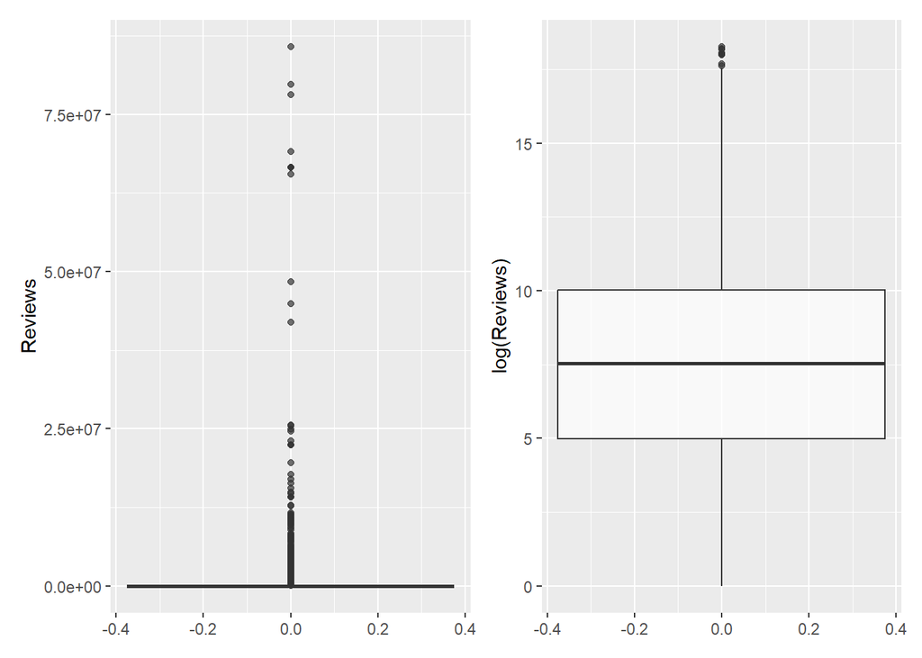

```r
#boxplot
b1 <- ggplot(playstore, aes(y = Reviews)) +
  geom_boxplot( alpha = 0.7)

b2 <- ggplot(playstore, aes(y = log(Reviews))) + #we try again with log(Reviews)
  geom_boxplot( alpha = 0.7)
b1 + b2
```

Boxplots: Again, the first boxplot represent the spread and distribution of the original scale. So its hard to identify something so we plot again with the logarithm of the review counts. The log-transformed reviews appears to be more symmetric, with the median line closer to the center of the box. The presence of outliers is visible.

#### Price

```r
#Measures of Central Tendency
summary(playstore$Price)
```

```
##    Length     Class      Mode
##     16516 character character
```

```r
Mode(playstore$Price)
```

```
## [1] "Free"
## attr(,"freq")
## [1] 15450
```

Replace the value “Free” with 0 and transform the column “Price” to numeric

```r
playstore$Price <- ifelse(playstore$Price == "Free", 0, playstore$Price) #for each value "Free" in the Price column, replace it with 0.

playstore$Price <- as.numeric(playstore$Price)

table(playstore$Price)
```

```
##
##          0    73.8342      74.58     78.309    88.7502    93.9708    96.2082
##      15450        163          1          1          6          1          2
##   111.1242     111.87   118.5822   120.0738    126.786   131.2608   148.4142
##         51          1          1          1          1          1        153
##     149.16    164.076    178.992   185.7042     186.45   190.9248   208.0782
##          4          1          1         46          1          1          1
##    216.282   222.9942     223.74   225.2316   229.7064   240.1476   260.2842
##          1        184          1          1          1          1         20
##    264.759    279.675   284.1498    287.133   289.3704   297.5742     298.32
##          1          1          1          1          1         85          2
##   319.9482   334.8642     335.61   342.3222   355.7466   360.9672    369.171
##          1         13          1          1          1          1          1
##   372.1542   409.4442   428.0892   429.5808   446.7342     447.48   469.1082
##        120         11          1          1         32          1          1
##   484.0242   521.3142   558.6042   577.2492   595.8942   633.1842    656.304
##          2         18          2          2         14          1          1
##   670.4742   707.7642   730.1382    742.071   745.0542    801.735   894.2142
##          9          2          1          1         29          1          8
##   968.7942  1043.3742  1098.5634  1117.9542  1192.5342  1267.1142  1341.6942
##          5          1          1          8          5          1          1
##  1416.2742  1490.8542  1789.1742  1863.7542  2087.4942  2236.6542  2385.8142
##          1          3          1          5          1          7          1
##  2534.9742  2833.2942  5592.7542 28339.6542 29085.4542 29831.2542
##          1          1          1          1          1          4
```

```r
#Measures of variability
var(playstore$Price)
```

```
## [1] 329150
```

```r
sd(playstore$Price)
```

```
## [1] 573.7159
```

```r
IQR(playstore$Price)
```

```
## [1] 0
```

```r
MeanAD(playstore$Price)
```

```
## [1] 57.59914
```

```r
kurtosis(playstore$Price)
```

```
## [1] 2521.307
```

```r
skewness(playstore$Price)
```

```
## [1] 49.21935
```

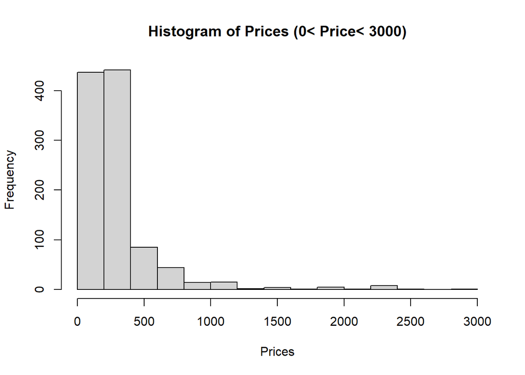

```r
#Histogram
hist(subset(playstore,Price > 0 & Price <3000)$Price,
     main="Histogram of Prices (0< Price< 3000)",
     xlab = "Prices")
```

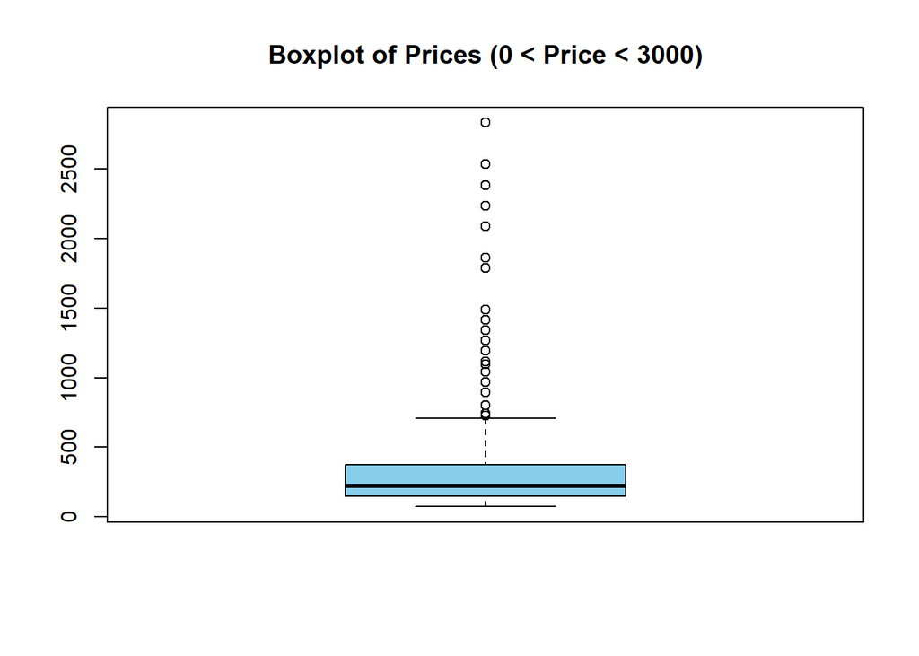

```r
#Boxplot
boxplot(subset(playstore, Price > 0 & Price < 3000)$Price,
        main = "Boxplot of Prices (0 < Price < 3000)",col = "skyblue")
```

Histogram: The hist shows a large concentration of items at the lower price range. The distribution is right skewed.

Boxplot: The median line is near the bottom of the box, we can infer that the median price is relatively low compared to the maximum price. There are lot of point beyond the top whisker which are consider as outliers.

#### Category

```r
unique(playstore$Category)
```

```
##  [1] "Finance"             "Music And Audio"     "Game Casual"
##  [4] "Business"            "Medical"             "Books And Reference"
##  [7] "Tools"               "Game"                "Travel And Local"
## [10] "Family"              "Game Simulation"     "Lifestyle"
## [13] "Comics"              "Education"           "Entertainment"
## [16] "Game Action"         "Social"              "Sports"
## [19] "Photography"         "Game Word"           "Game Trivia"
## [22] "Communication"       "News And Magazines"  "Game Board"
## [25] "House And Home"      "Personalization"     "Game Puzzle"
## [28] "Productivity"        "Health And Fitness"  "Shopping"
## [31] "Art And Design"      "Weather"             "Maps And Navigation"
## [34] "Dating"              "Game Arcade"         "Game Role Playing"
## [37] "Game Educational"    "Video Players"       "Game Strategy"
## [40] "Food And Drink"      "Game Sports"         "Auto And Vehicles"
## [43] "Events"              "Game Adventure"      "Parenting"
## [46] "Libraries And Demo"  "Game Racing"         "Game Card"
## [49] "Game Music"          "Game Casino"         "Beauty"
```

```r
length(unique(playstore$Category))
```

```
## [1] 51
```

51 categories

```r
frequency_table <- table(playstore$Category)
frequency_table
```

```
##
##      Art And Design   Auto And Vehicles              Beauty Books And Reference
##                  89                 126                  55                 741
##            Business              Comics       Communication              Dating
##                 521                  48                 365                 119
##           Education       Entertainment              Events              Family
##                1440                 927                  57                 686
##             Finance      Food And Drink                Game         Game Action
##                 667                 222                 426                 235
##      Game Adventure         Game Arcade          Game Board           Game Card
##                 130                 280                 109                 192
##         Game Casino         Game Casual    Game Educational          Game Music
##                  71                 287                 179                  44
##         Game Puzzle         Game Racing   Game Role Playing     Game Simulation
##                 398                 120                 169                 192
##         Game Sports       Game Strategy         Game Trivia           Game Word
##                 121                 166                  71                 121
##  Health And Fitness      House And Home  Libraries And Demo           Lifestyle
##                 441                  84                  53                 659
## Maps And Navigation             Medical     Music And Audio  News And Magazines
##                 179                 326                 526                 413
##           Parenting     Personalization         Photography        Productivity
##                  64                 440                 408                 570
##            Shopping              Social              Sports               Tools
##                 378                 271                 397                1231
##    Travel And Local       Video Players             Weather
##                 369                 222                 111
```

```r
names(frequency_table)[which.max(frequency_table)]
```

```
## [1] "Education"
```

```r
names(frequency_table)[which.min(frequency_table)]
```

```
## [1] "Game Music"
```

Most frequent category is “Education” and the less frequent is “Game Music”

A bar plot of the count of each category.

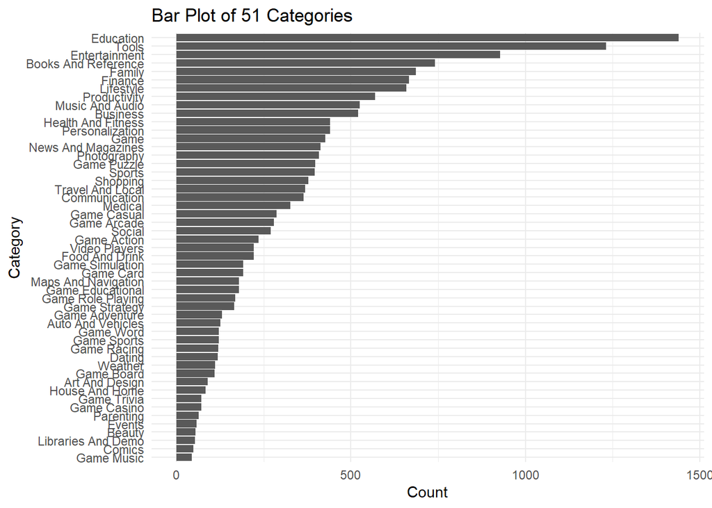

```r
#Barplot per Category
frequency_table <- playstore %>%
  group_by(Category) %>%
  summarise(Count = n())

ggplot(frequency_table, aes(x=reorder(Category, Count), y=Count)) +
  geom_bar(stat="identity") +
  coord_flip() +
  theme_minimal() +
  labs(x="Category", y="Count", title="Bar Plot of 51 Categories")
```

Create new column called “newCategory” by grouping several existing categories into broader ones.

```r
#playstore new category

playstore$newCategory <- with(playstore,
                              ifelse(grepl("Game", Category), "Game",
                                     ifelse(Category %in% c('Lifestyle', 'Health And Fitness', 'Beauty'), 'Lifestyle and Personal Care',
                                            ifelse(Category %in% c('Travel And Local', 'Maps And Navigation'), 'Navigation and Travel',
                                                   ifelse(Category %in% c('Shopping', 'Food And Drink'), 'Shopping and Services', Category))))
)

unique(playstore$newCategory)
```

```
##  [1] "Finance"                     "Music And Audio"
##  [3] "Game"                        "Business"
##  [5] "Medical"                     "Books And Reference"
##  [7] "Tools"                       "Navigation and Travel"
##  [9] "Family"                      "Lifestyle and Personal Care"
## [11] "Comics"                      "Education"
## [13] "Entertainment"               "Social"
## [15] "Sports"                      "Photography"
## [17] "Communication"               "News And Magazines"
## [19] "House And Home"              "Personalization"
## [21] "Productivity"                "Shopping and Services"
## [23] "Art And Design"              "Weather"
## [25] "Dating"                      "Video Players"
## [27] "Auto And Vehicles"           "Events"
## [29] "Parenting"                   "Libraries And Demo"
```

```r
playstore$newCategory <- as.factor(playstore$newCategory) # convert the newCategory to factor
playstore_numeric_and_factor <- playstore[sapply(playstore, function(x) is.numeric(x) || is.factor(x))] # Create dataframe which includes only numeric or factors columns

playstore_numeric <- playstore %>% select_if(is.numeric)

playstore_numeric_scaled <- scale(playstore_numeric) # Standardizes the numeric data
```

Perform a k-means clustering on our dataset. We separate factor columns, from the dataframe we created above, playstore_numeric_and_factor, and we combine these with a scaled version of the numeric columns, ensuring that only complete cases with no missing values are used. The kmeans seperate the data into five clusters. Each entry is assigned to a cluster and categories are merged by assigning the most frequent category within each cluster to create a Merged_Category.

```r
# Select only the factor columns from playstore_numeric_and_factor
factor_columns <- playstore_numeric_and_factor[sapply(playstore_numeric_and_factor, is.factor)]

# Combine the factor columns with the scaled numeric dataframe
playstore_combined <- cbind(playstore_numeric_scaled, factor_columns)

playstore_numeric <- playstore %>% select_if(is.numeric)

playstore_numeric_scaled <- scale(playstore_numeric,center = TRUE,scale = TRUE)
playstore_numeric_scaled <- playstore_numeric_scaled[complete.cases(playstore_numeric_scaled), ]

# Perform k-means clustering
set.seed(123)  # for reproducibility
k <- 5  # define the number of clusters
km_res <- kmeans(playstore_numeric_scaled, centers = k, nstart = 25)

# Add the cluster assignments
playstore$Cluster <- km_res$cluster

# Merge the categories based on the most frequent category in each cluster
playstore <- playstore %>%
  group_by(Cluster) %>%
  mutate(Merged_Category = names(which.max(table(Category)))) %>%
  ungroup()

unique(playstore$Cluster)
```

```
## [1] 2 4 1 3 5
```

```r
unique(playstore$Merged_Category)
```

```
## [1] "Tools"     "Education" "Finance"   "Lifestyle"
```

```r
table(playstore$Merged_Category)
```

```
##
## Education   Finance Lifestyle     Tools
##      8269      1049         6      7192
```

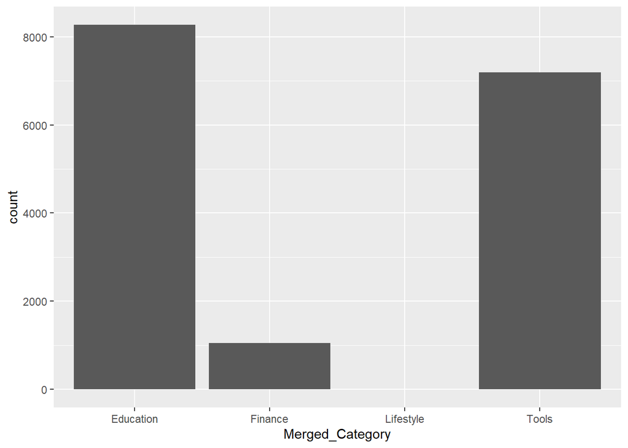

```r
ggplot(data=playstore,mapping=aes(x=Merged_Category)) + geom_bar()
```

#### Offered_By

```r
anyDuplicated(playstore$Offered_By) #320 duplicates
```

```
## [1] 320
```

```r
#unique(playstore$Offered_By) # see the values of Offered_By
frequency_table <- table(playstore$Offered_By)
max_offered_by <- names(frequency_table)[which.max(frequency_table)]
names(frequency_table)[which.min(frequency_table)] #"ps_id-1"
```

```
## [1] "ps_id-1"
```

```r
max_count <- max(frequency_table)
most_frequent_ids <- names(which(frequency_table == max_count)) #the most frequent publisher
frequency_table[most_frequent_ids] #it appear 20 times
```

```
## ps_id-863
##        20
```

```r
#Calculate the count of IDs for each number of occurrences
ids_for_each_occurrence <- playstore%>%
  group_by(Offered_By) %>%
  summarise(count = n()) %>%
  group_by(count) %>%
  summarise(num_ids = n())
ids_for_each_occurrence
```

```
## # A tibble: 11 × 2
##    count num_ids
##    <int>   <int>
##  1     1   14783
##  2     2     590
##  3     3     105
##  4     4      16
##  5     5      10
##  6     6      11
##  7     7       1
##  8     8       1
##  9     9       1
## 10    14       1
## 11    20       1
```

```r
playstore[playstore$Offered_By == max_offered_by ,]$Category
```

```
##  [1] "Finance"             "Tools"               "House And Home"
##  [4] "Education"           "Lifestyle"           "Books And Reference"
##  [7] "Education"           "Finance"             "Finance"
## [10] "Business"            "Shopping"            "Books And Reference"
## [13] "Comics"              "Game Strategy"       "Social"
## [16] "News And Magazines"  "Entertainment"       "Lifestyle"
## [19] "Entertainment"       "Tools"
```

#### Size

```r
#unique(playstore$Size) # See the values of Size

frequency_table <- table(playstore$Size)
#frequency_table
names(frequency_table)[which.max(frequency_table)]
```

```
## [1] "Varies with device"
```

```r
names(frequency_table)[which.min(frequency_table)]
```

```
## [1] "1,005k"
```

```r
sum(playstore$Size == "Varies with device")
```

```
## [1] 1918
```

```r
(sum(playstore$Size == "Varies with device") / nrow(playstore))*100
```

```
## [1] 11.61298
```

We have 11.6% which is more than 10% so most probably we will not use it later in our model

```r
#check what measurements containing in the size column
unit <- substr(playstore$Size, nchar(playstore$Size), nchar(playstore$Size))
unique(unit)
```

```
## [1] "e" "M" "k"
```

```r
num <- as.numeric(sub("[^0-9.]", "", playstore$Size)) # Extract numeric part
unit <- substring(playstore$Size, nchar(playstore$Size))
#unit
```

```r
#convert size to bytes
# Apply the function to the Size column
suppressWarnings({
playstore$Size <- sapply(playstore$Size, convert_size_to_bytes, USE.NAMES = FALSE)
})
sum(is.na(playstore$Size))
```

```
## [1] 1922
```

```r
nrow(playstore)
```

```
## [1] 16516
```

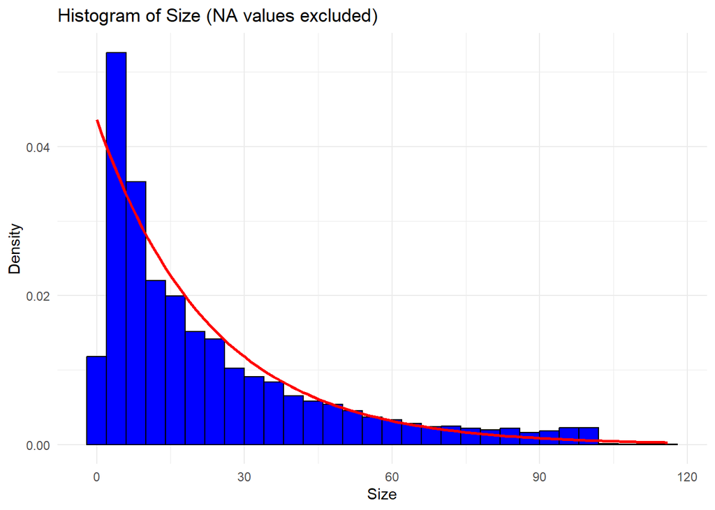

```r
#Histogram with exponential density
ggplot(playstore[!is.na(playstore$Size), ], aes(x = Size)) +
  geom_histogram(fill = "blue", color = "black", bins = 30, aes(y = ..density..)) +  # Use density instead of frequency
  labs(x = "Size", y = "Density", title = "Histogram of Size (NA values excluded)") +
  # Calculate the rate for the exponential distribution
  # Add exponential distribution curve using stat_function
  stat_function(fun = function(x) { dexp(x, rate = 1/mean(playstore$Size, na.rm = TRUE)) },
                color = "red", size = 1) + theme_minimal()
```

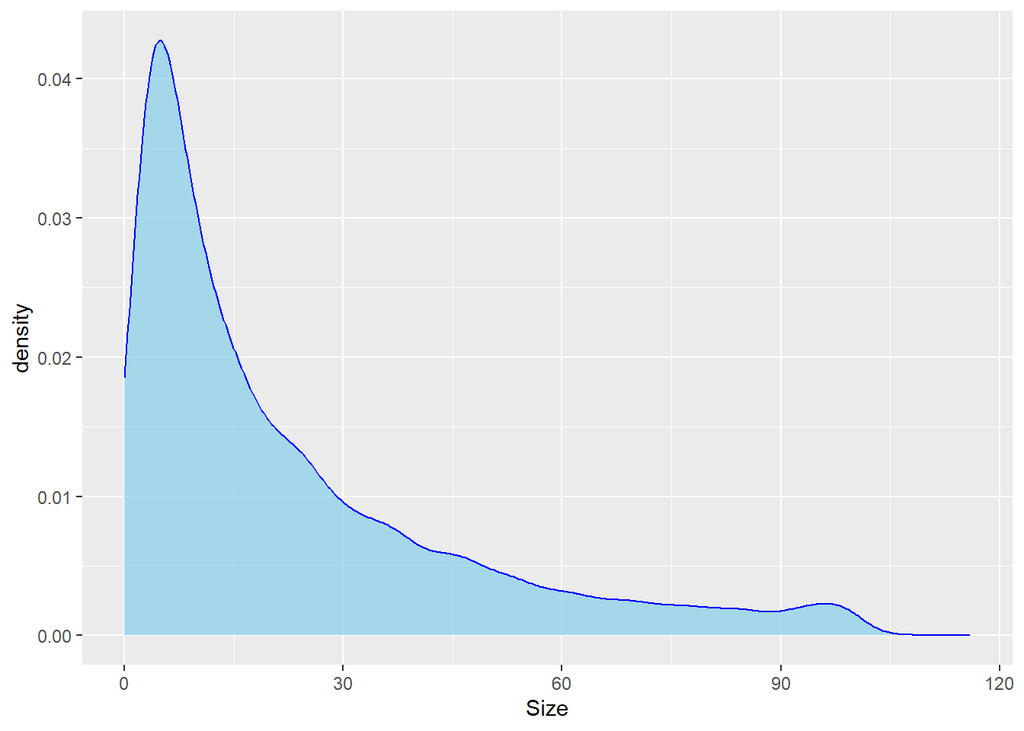

```r
#Density Plot
ggplot(playstore, aes(x = Size)) +
  geom_density(fill = "skyblue", color = "blue", alpha = 0.7) + labs(x="Size")
```

```r
ks.test(playstore$Size, "pexp", rate =  1 / mean(playstore$Size, na.rm = TRUE))
```

```
##
##  Asymptotic one-sample Kolmogorov-Smirnov test
##
## data:  playstore$Size
## D = 0.060449, p-value < 2.2e-16
## alternative hypothesis: two-sided
```

We reject the null hypothesis despite the fact that the hist seems to follow exponential distribution with rate = $\frac{1}{\mu_{\text{Size}}}$.

#### Content_Rating

We have `Content_Rating` values, with “Everyone” to be 10 times most usual than the others.

```r
unique(playstore$Content_Rating)
```

```
## [1] "Everyone"        "Teen"            "Everyone 10+"    "Mature 17+"
## [5] "Adults only 18+" "Unrated"
```

```r
frequency_table <- table(playstore$Content_Rating)
frequency_table
```

```
##
## Adults only 18+        Everyone    Everyone 10+      Mature 17+            Teen
##               4           13895             596             429            1590
##         Unrated
##               2
```

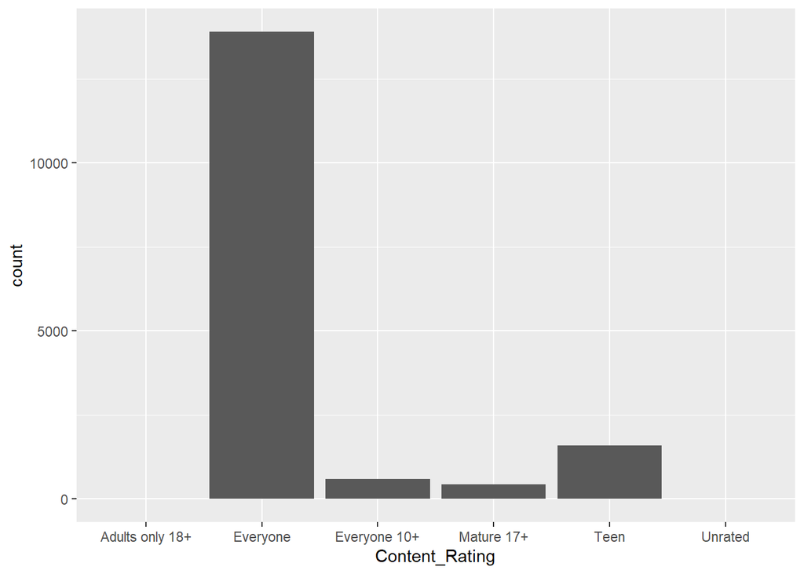

```r
ggplot(data = playstore, mapping = aes(x = Content_Rating)) + geom_bar()
```

#### Last_Updated_On

```r
names(frequency_table)[which.max(frequency_table)]
```

```
## [1] "Everyone"
```

```r
names(frequency_table)[which.min(frequency_table)]
```

```
## [1] "Unrated"
```

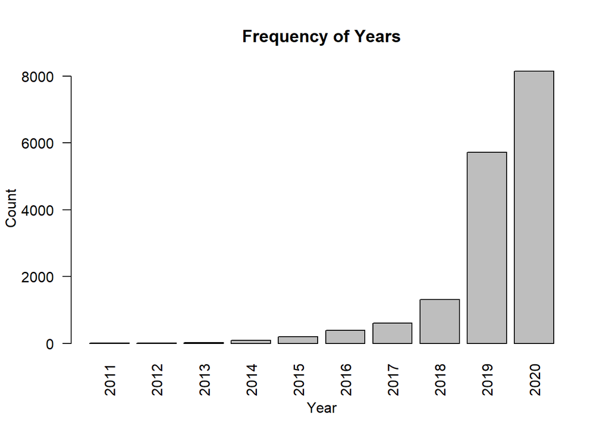

```r
playstore$date_column <- as.Date(playstore$Last_Updated_On, format = "%b %d %Y") #change the format of the date to "year - month - day"


playstore$year <- format(playstore$date_column, "%Y") #extract the year from each date

year_count <- table(playstore$year)

# Create a barplot with the frequencies
barplot(year_count, main = "Frequency of Years", xlab = "Year", ylab = "Count", las = 2)
```

From the barplot we can observe an increasing trend over the years with the highest counts at the last 2 years. The increase might indicate a growing number of items being added to the dataset each year.

```r
playstore$Last_Updated_On <- as.Date(playstore$Last_Updated_On, format = "%b %d %Y") #converts the "Last Update On" column from character or factor into date object

playstore$Last_Updated_On <- as.numeric(difftime(playstore$Last_Updated_On, min(playstore$Last_Updated_On), units = "days")) # after converting the column to dates, we calculate the difference in days between each date in the Last_Updated_On column and the oldest date in that column.
head(playstore$Last_Updated_On)
```

```
## [1] 3293 3253 3289 3290 2770 2838
```

```r
#remove columns date_column and year
playstore <- subset(playstore, select = -date_column)
playstore <- subset(playstore, select = -year)
```

#### Downloads

```r
unique(playstore$Downloads) # see the values of Downloads
```

```
##  [1] "100,000+"       "5,000+"         "10,000+"        "10,000,000+"
##  [5] "50,000+"        "1,000,000+"     "5,000,000+"     "500,000+"
##  [9] "1,000+"         "1,000,000,000+" "50,000,000+"    "100+"
## [13] "100,000,000+"   "500+"           "10+"            "50+"
## [17] "500,000,000+"   "5,000,000,000+"
```

```r
playstore$Downloads <- gsub(",", "", playstore$Downloads)  # Remove commas
playstore$Downloads <- gsub("\\+", "", playstore$Downloads) # Remove the plus sign
playstore$Downloads <- as.numeric(playstore$Downloads)      # Convert to numeric
```

```r
frequency_table <- table(playstore$Downloads)
frequency_table
```

```
##
##    10    50   100   500  1000  5000 10000 50000 1e+05 5e+05 1e+06 5e+06 1e+07
##    91    84   508   364  1221   763  2239  1243  3158  1360  2707   912  1277
## 5e+07 1e+08 5e+08 1e+09 5e+09
##   247   266    42    33     1
```

```r
names(frequency_table)[which.max(frequency_table)] #"1e+05"
```

```
## [1] "1e+05"
```

```r
names(frequency_table)[which.min(frequency_table)] #"5e+09"
```

```
## [1] "5e+09"
```

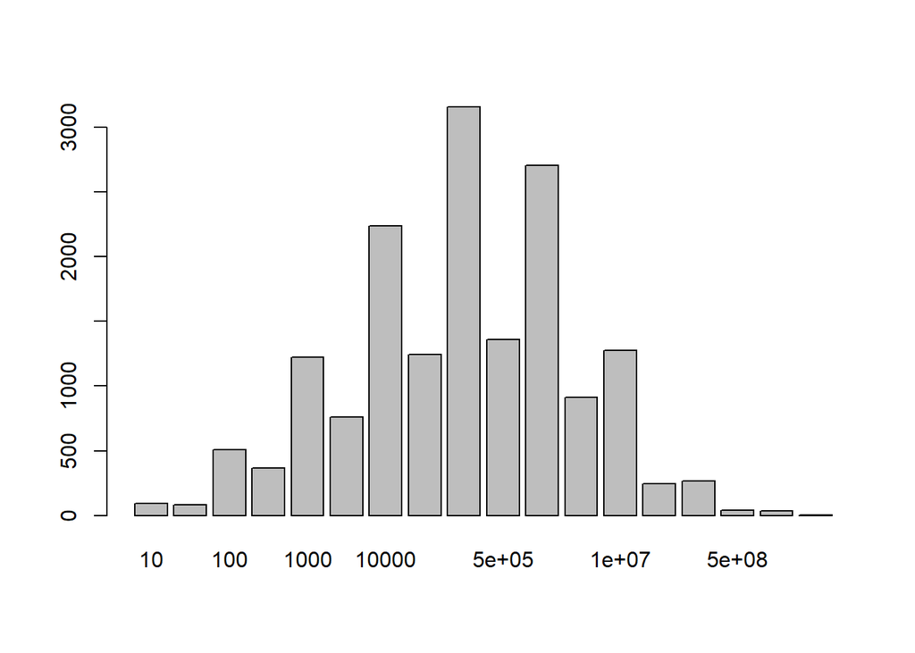

```r
barplot(frequency_table)
```

Check if the frequency table follows any Normal distribution.

```r
lillie.test(frequency_table)
```

```
##
##  Lilliefors (Kolmogorov-Smirnov) normality test
##
## data:  frequency_table
## D = 0.16957, p-value = 0.1864
```

We do not reject the null hypothesis. That means that the table above follows a Normal distribution.

Check if the frequency table follows the standard normal distribution

```r
ks.test(frequency_table, "pnorm")
```

```
##
##  Exact one-sample Kolmogorov-Smirnov test
##
## data:  frequency_table
## D = 0.94444, p-value = 2.22e-16
## alternative hypothesis: two-sided
```

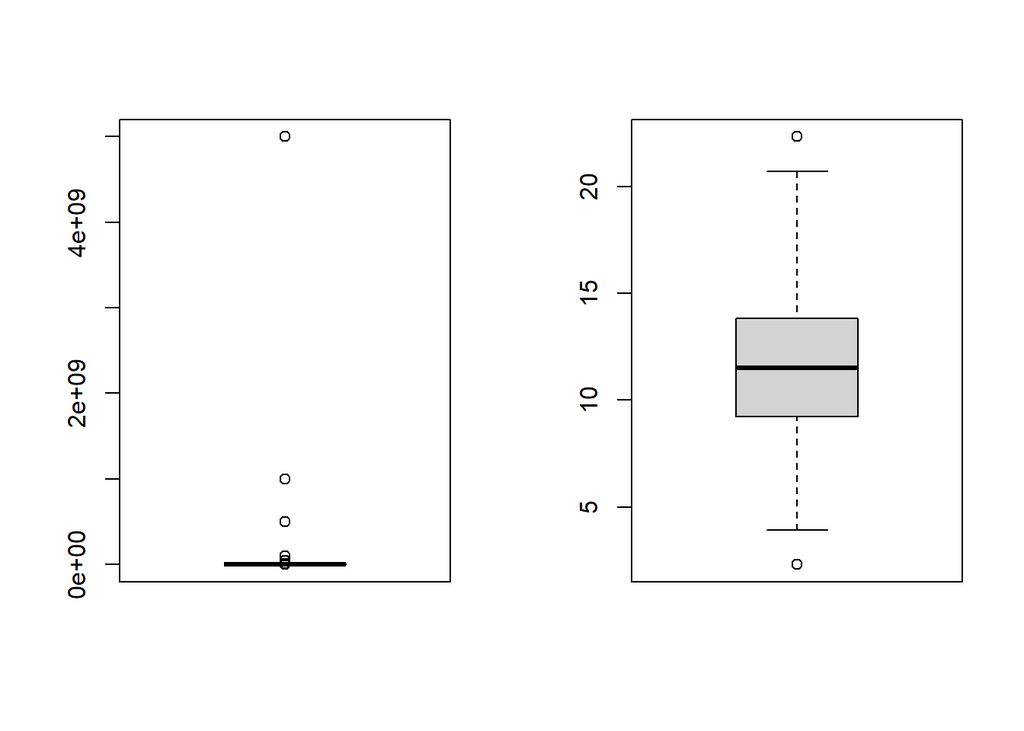

```r
par(mfrow=c(1,2))
boxplot(playstore$Downloads)
boxplot(log(playstore$Downloads))
```

In the left boxplot using the original values without any tranformation the median is very close to the bottom of the box, which this means that at least half of the download counts are relatively low. There are several outliers above the upper whisker. The distribution is highly right-skewed. The right boxplot displays the distribution of download counts after a logarithm transformation. The median now is closer to the center of the box, which suggest that the transformed data has a symmetric distribution. The range of the data is more compact and the box appears more proportionally spread, indicating less skewness in the log-transformed data. Outliers are still present but appear less extreme on the logarithmic scale.

We created 8 classes for our response variable.

```r
num_classes <- 8
#We transform the column to numeric
playstore$Downloads <- as.numeric(as.character(playstore$Downloads))


#We calculate the quantiles of the column and divide the data into 8 groups

#The seq function is used to create a sequence from 0 to 1 with length equal to num_classes + 1 to create the correct number of intervals.
quantiles <- quantile(playstore$Downloads, probs = seq(0, 1, length.out = num_classes + 1), na.rm = TRUE)
quantiles
```

```
##    0% 12.5%   25% 37.5%   50% 62.5%   75% 87.5%  100%
## 1e+01 1e+03 1e+04 5e+04 1e+05 5e+05 1e+06 5e+06 5e+09
```

```r
#creating a new column 'Class'.
#cut function is used to divide the 'Downloads' into bins defined by the previously calculated quantiles.
#we also make sure that the lowest value is included in the first bin.
playstore <- playstore %>%
  mutate(Class = cut(Downloads, breaks = quantiles, labels = FALSE, include.lowest = TRUE))
playstore$Class <- playstore$Class-1

class_summary <- playstore %>%
  group_by(Class) %>%
  summarise(
    Min_Downloads = min(Downloads),
    Max_Downloads = max(Downloads),
    Count = n()
  )

class_summary
```

```
## # A tibble: 8 × 4
##   Class Min_Downloads Max_Downloads Count
##   <dbl>         <dbl>         <dbl> <int>
## 1     0            10          1000  2268
## 2     1          5000         10000  3002
## 3     2         50000         50000  1243
## 4     3        100000        100000  3158
## 5     4        500000        500000  1360
## 6     5       1000000       1000000  2707
## 7     6       5000000       5000000   912
## 8     7      10000000    5000000000  1866
```

```r
table(playstore$Class)
```

```
##
##    0    1    2    3    4    5    6    7
## 2268 3002 1243 3158 1360 2707  912 1866
```

```r
playstore$Class <- as.factor(playstore$Class)
```

#### Correlations and Covariations

```r
numeric_cols <- sapply(playstore, is.numeric)
numeric_data <- playstore[numeric_cols]
numeric_data$Class <- NULL
numeric_data$Size <- NULL
# Now playstore$numeric_downloads is a numeric representation of the Downloads
# You can check correlation with another numeric column like this:
cor_matrix <- cor(numeric_data, use = "everything")
cor_matrix
```

```
##                          Rating      Reviews         Price Last_Updated_On
## Rating              1.000000000  0.030852173 -0.0190889591     0.108443763
## Reviews             0.030852173  1.000000000 -0.0051210310     0.021605825
## Price              -0.019088959 -0.005121031  1.0000000000    -0.025486888
## Last_Updated_On     0.108443763  0.021605825 -0.0254868881     1.000000000
## Downloads           0.018249538  0.602444225 -0.0058506437     0.022678203
## Major_Version      -0.001649276 -0.001287102 -0.0004875643    -0.005208203
## OS_Version_Numeric -0.008540505  0.004293486 -0.0074921364     0.530457425
## Cluster             0.767482859  0.073465771  0.0363083510     0.075024772
##                        Downloads Major_Version OS_Version_Numeric     Cluster
## Rating              0.0182495378 -0.0016492764      -0.0085405054  0.76748286
## Reviews             0.6024442255 -0.0012871021       0.0042934859  0.07346577
## Price              -0.0058506437 -0.0004875643      -0.0074921364  0.03630835
## Last_Updated_On     0.0226782033 -0.0052082028       0.5304574253  0.07502477
## Downloads           1.0000000000 -0.0009983606       0.0109481884  0.05508091
## Major_Version      -0.0009983606  1.0000000000       0.0002153192 -0.01538045
## OS_Version_Numeric  0.0109481884  0.0002153192       1.0000000000 -0.04684757
## Cluster             0.0550809126 -0.0153804486      -0.0468475741  1.00000000
```

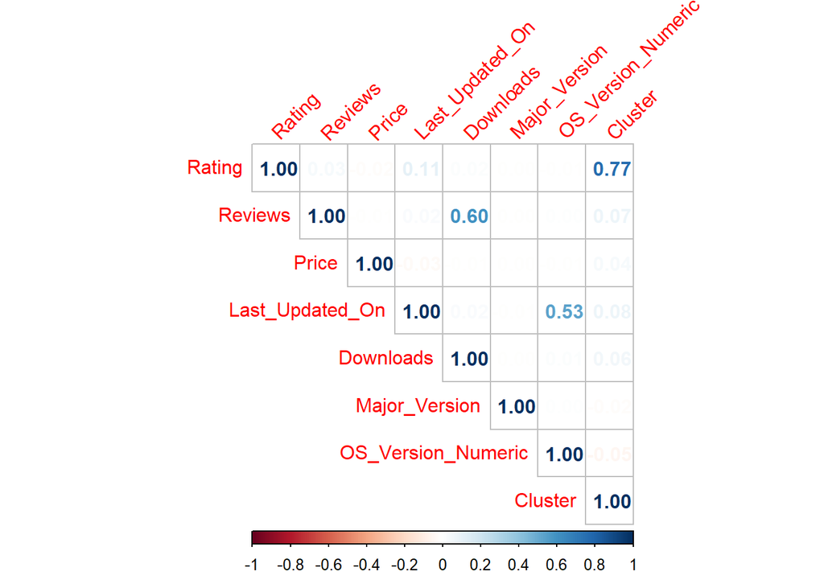

```r
# Plot the correlation matrix
corrplot(cor_matrix, type = "upper", method = "number", number.cex = 1, cl.pos = "b",
         tl.col = "red",
         tl.srt = 45)
```

We can see that Rating has no correlation with Downloads and also it’s not correlated with the other predictors, except ‘Cluster’. Reviews is only correlated with ‘Downloads’. Lastly, ‘Last_Updated_On’ seems to be slightly correlated with ‘OS_Version_Numeric’. There are no other correlations between the features.

Content_Rating - Rating

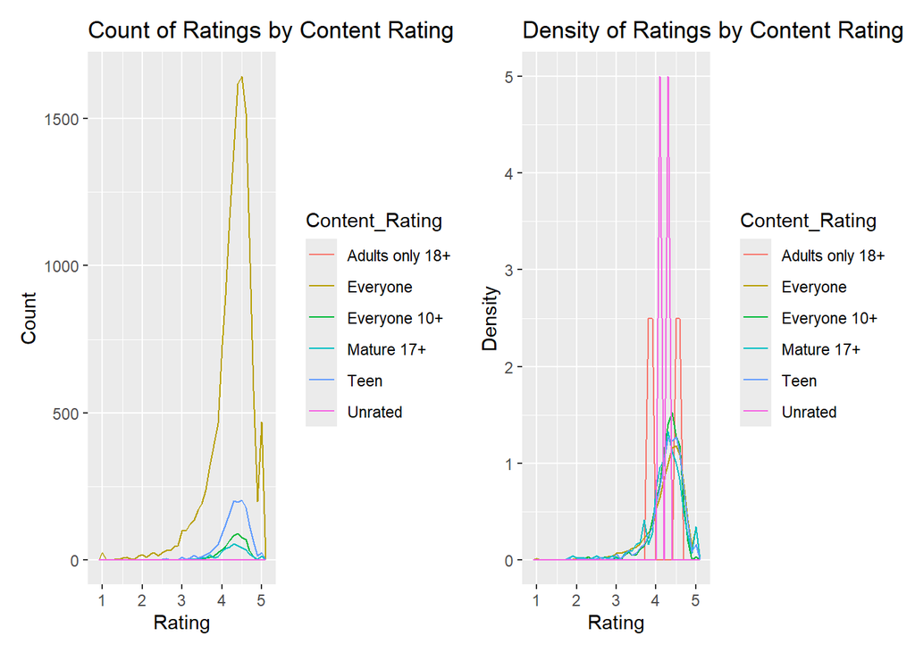

```r
g1 = ggplot(data = playstore, mapping = aes(x = Rating)) +
  geom_freqpoly(mapping = aes(colour = Content_Rating), binwidth = 0.1) +
  labs(x = "Rating", y = "Count", title = "Count of Ratings by Content Rating")

g2 = ggplot(data = playstore, mapping = aes(x = Rating, y = ..density..)) +
  geom_freqpoly(mapping = aes(colour = Content_Rating), binwidth = 0.1) +
  labs(x = "Rating", y = "Density", title = "Density of Ratings by Content Rating")
g1 + g2
```

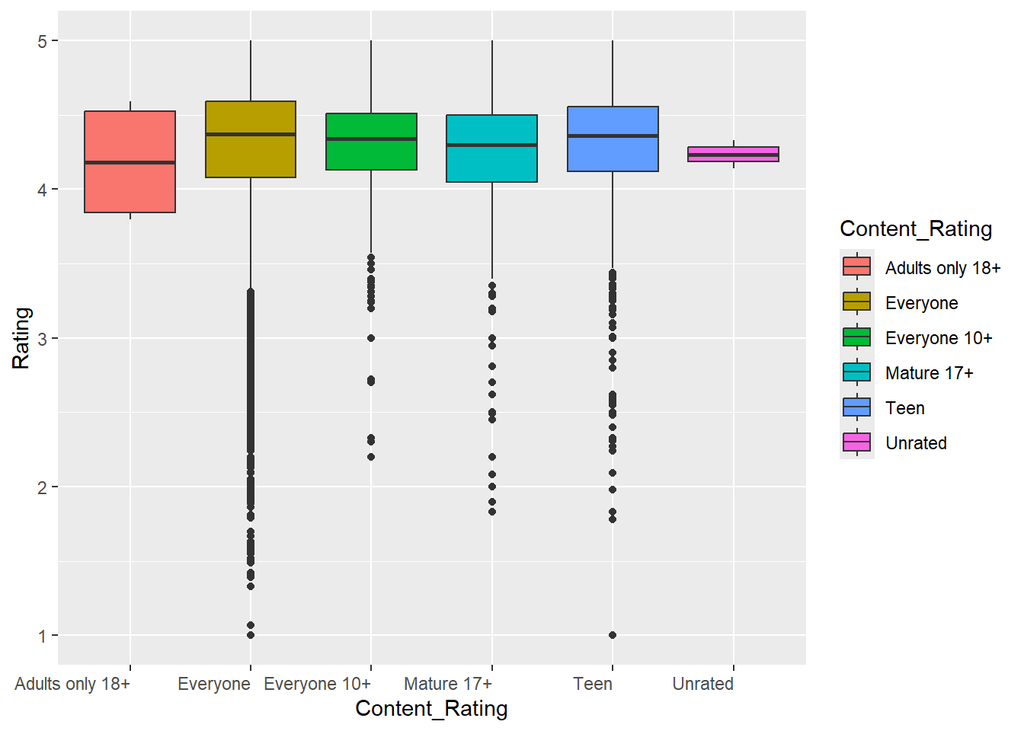

```r
#Boxplot Rating - Content_Rating
ggplot(playstore, aes(x = Content_Rating, y = Rating)) +
  geom_boxplot(aes(fill = Content_Rating)) +
  theme(axis.text.x = element_text(angle = 0, hjust = 1))
```

In the boxplots with the distribution of ratings across different content ratings , we can see that the medians are above 4 for all categories, suggesting that apps tend to be rated favorably. All contents except of ’Adults only 18+’ and ’unrated’ has outliers. All the outliers are below the lower whisker. Categories like ’Everyone’ and ’Teen’ have more outliers.

Boxplots with various columns and the Class feature.

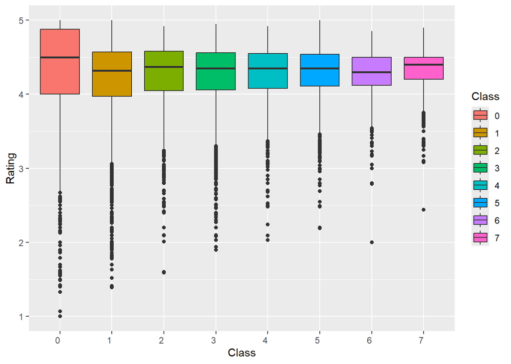

```r
#Boxplot Class - Rating
ggplot(playstore, aes(x = as.factor(playstore$Class), y = Rating)) +
  geom_boxplot(aes(fill = as.factor(playstore$Class))) +
  theme(axis.text.x = element_text(angle = 0, hjust = 1)) +
  labs(x="Class",y="Rating", fill = "Class")
```

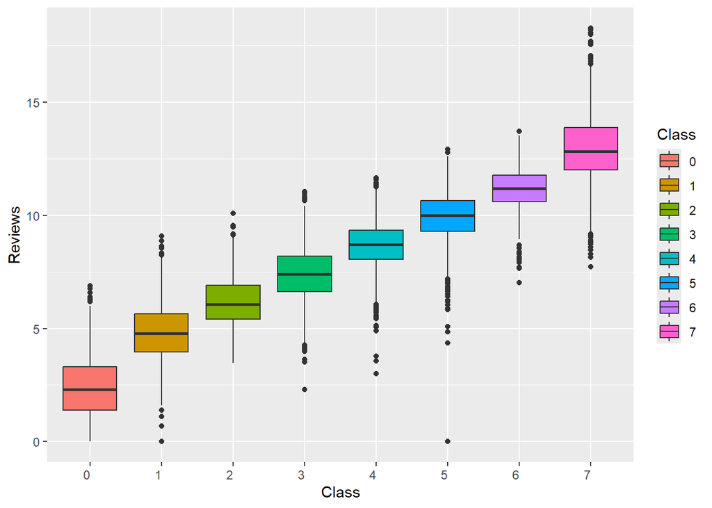

```r
#Boxplot Class - Reviews
ggplot(playstore, aes(x =as.factor(playstore$Class), y = log(Reviews))) +
  geom_boxplot(aes(fill = as.factor(playstore$Class))) +
  theme(axis.text.x = element_text(angle = 0, hjust = 1))+
  labs(x="Class",y="Reviews", fill = "Class")
```

```r
playstore_filtered <- subset(playstore, Price > 0 & Price < 3000)
sum(playstore_filtered$Class == 6)
```

```
## [1] 1
```

```r
sum(playstore_filtered$Class == 7)
```

```
## [1] 1
```

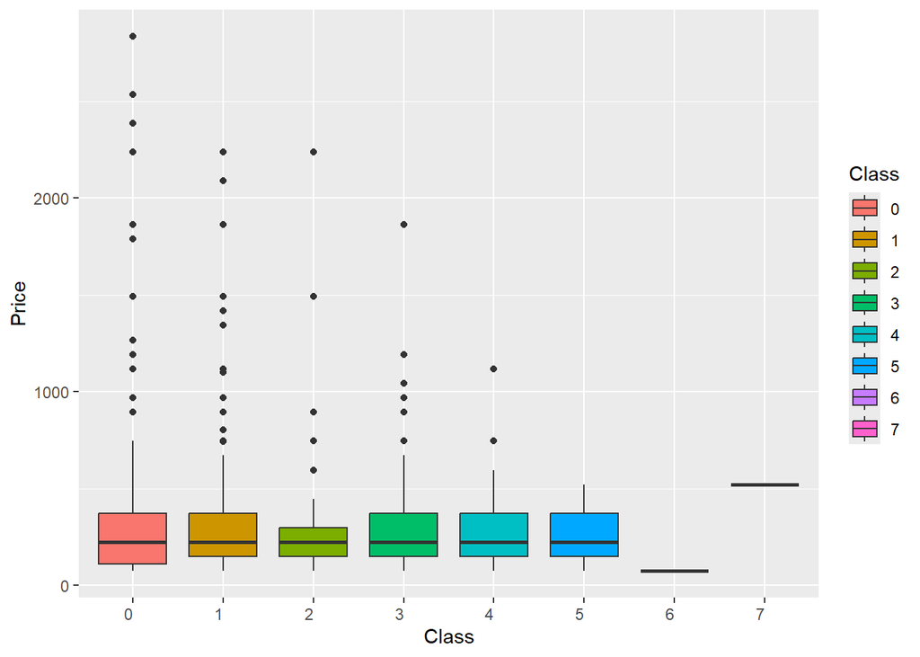

```r
ggplot(playstore_filtered, aes(x = as.factor(Class), y = Price)) +
  geom_boxplot(aes(fill = as.factor(Class))) +
  theme(axis.text.x = element_text(angle = 0, hjust = 1))+
    labs(x="Class",y="Price", fill = "Class")
```

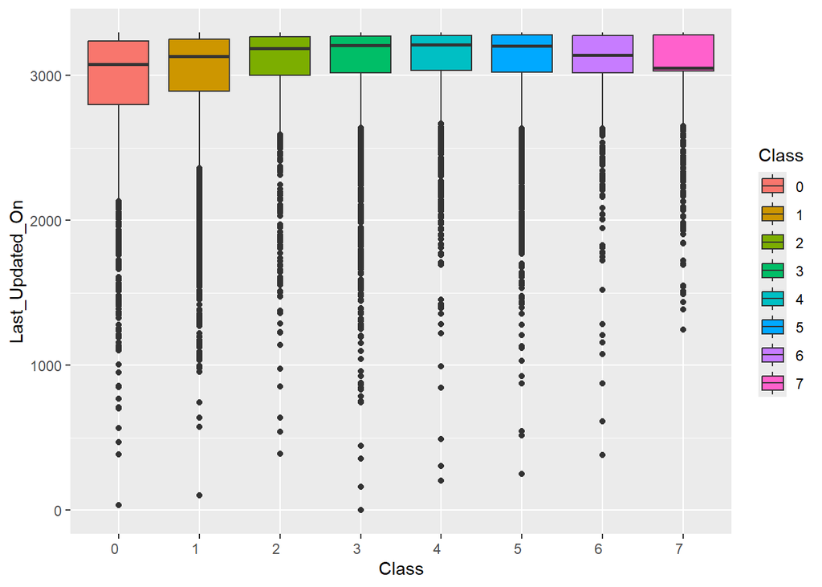

```r
ggplot(playstore, aes(x = as.factor(Class), y = Last_Updated_On)) +
  geom_boxplot(aes(fill = as.factor(Class))) +
  theme(axis.text.x = element_text(angle = 0, hjust = 1))+
    labs(x="Class",y="Last_Updated_On", fill = "Class")
```

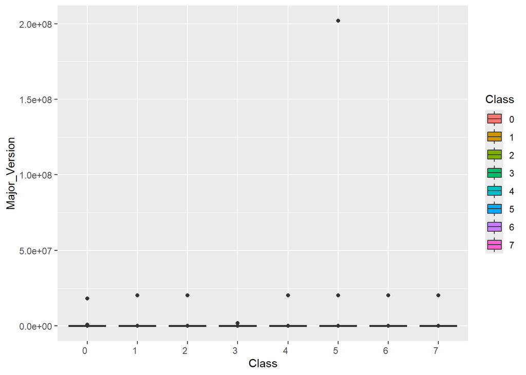

```r
ggplot(playstore, aes(x = as.factor(Class), y = Major_Version)) +
  geom_boxplot(aes(fill = as.factor(Class))) +
  theme(axis.text.x = element_text(angle = 0, hjust = 1))+
    labs(x="Class",y="Major_Version", fill = "Class")
```

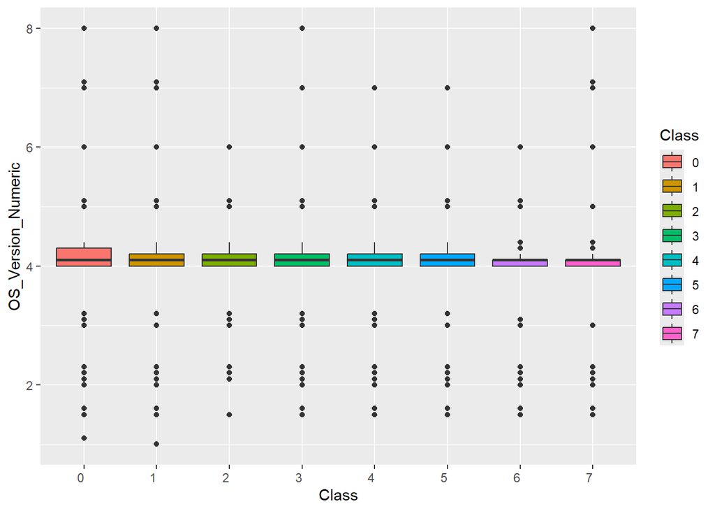

```r
ggplot(playstore, aes(x = as.factor(Class), y = OS_Version_Numeric)) +
  geom_boxplot(aes(fill = as.factor(Class))) +
  theme(axis.text.x = element_text(angle = 0, hjust = 1))+
    labs(x="Class",y="OS_Version_Numeric", fill = "Class")
```

Two categorical:

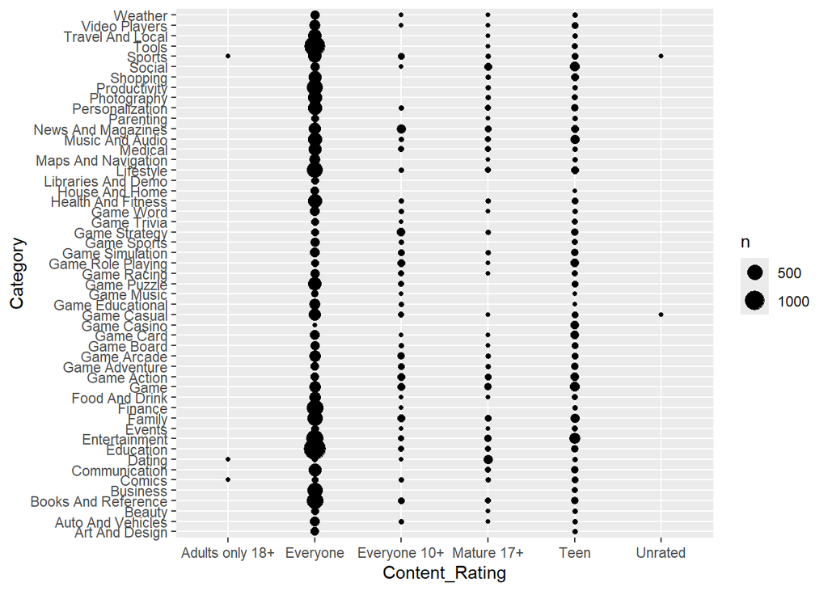

```r
#Category - Content_Rating
ggplot(data = playstore) + geom_count(mapping = aes(x = Content_Rating, y = Category))
```

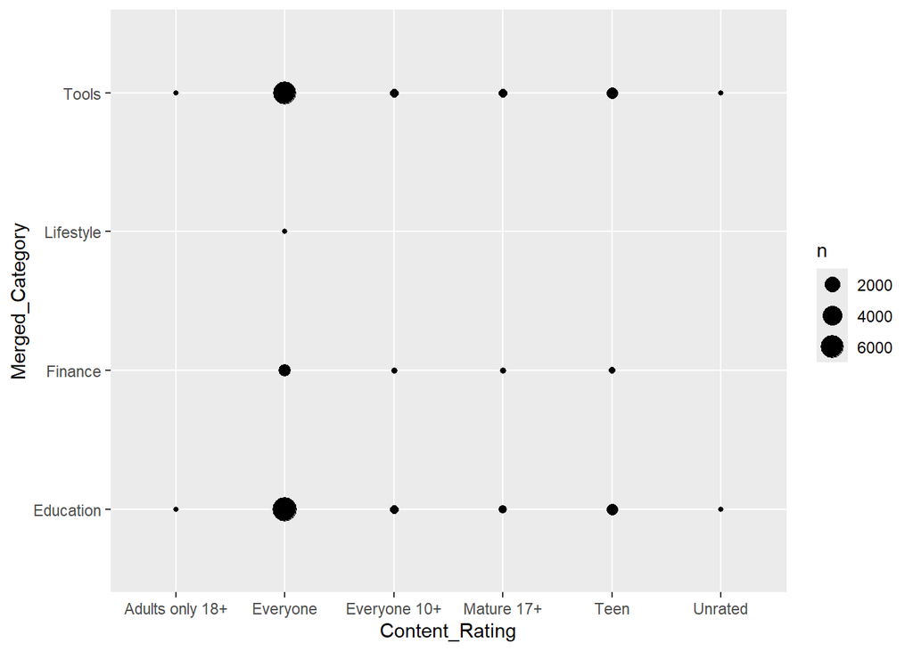

```r
ggplot(data = playstore) + geom_count(mapping = aes(x = Content_Rating, y = Merged_Category))
```

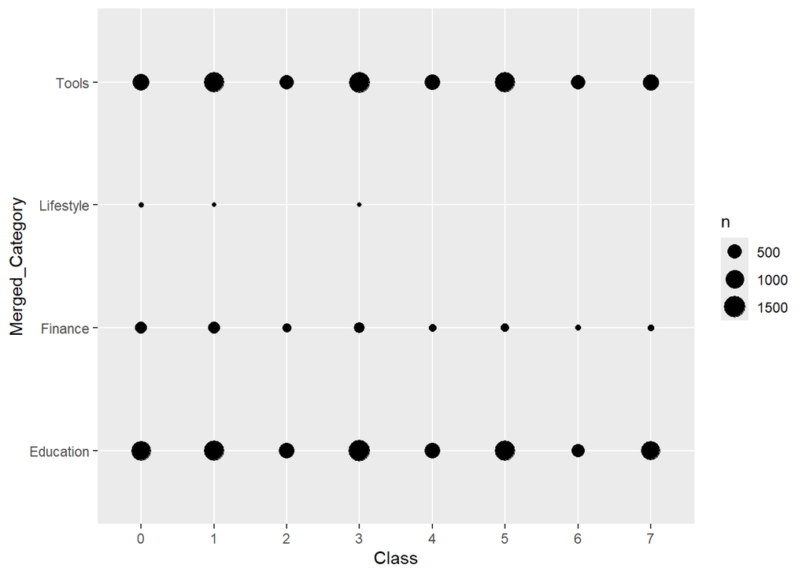

```r
ggplot(data = playstore) +
  geom_count(mapping = aes(x = as.factor(Class), y = Merged_Category)) +
  xlab("Class")
```

Continuous - Continuous:

Reviews - Rating

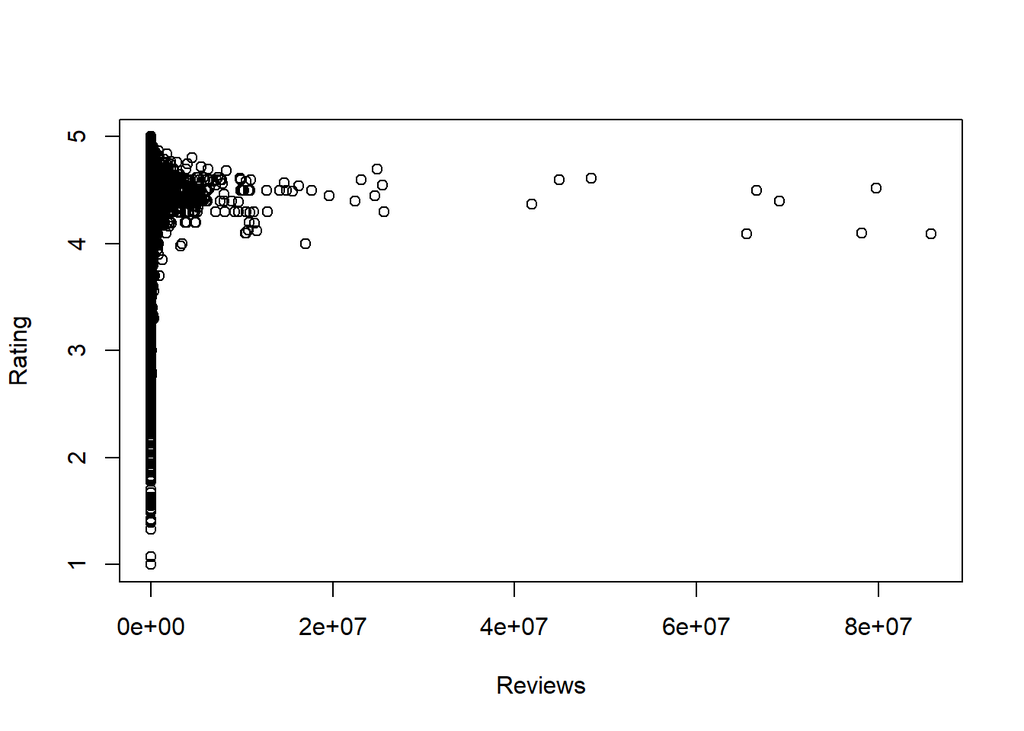

```r
# Reviews - Rating
plot(playstore$Reviews, playstore$Rating, xlab ="Reviews", ylab = "Rating")
```

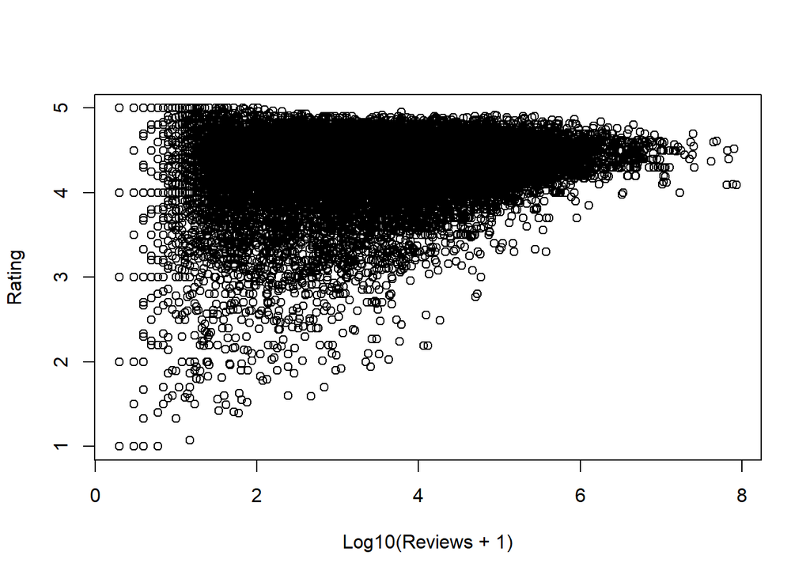

```r
plot(log10(playstore$Reviews + 1), playstore$Rating, xlab ="Log10(Reviews + 1)", ylab = "Rating")
```

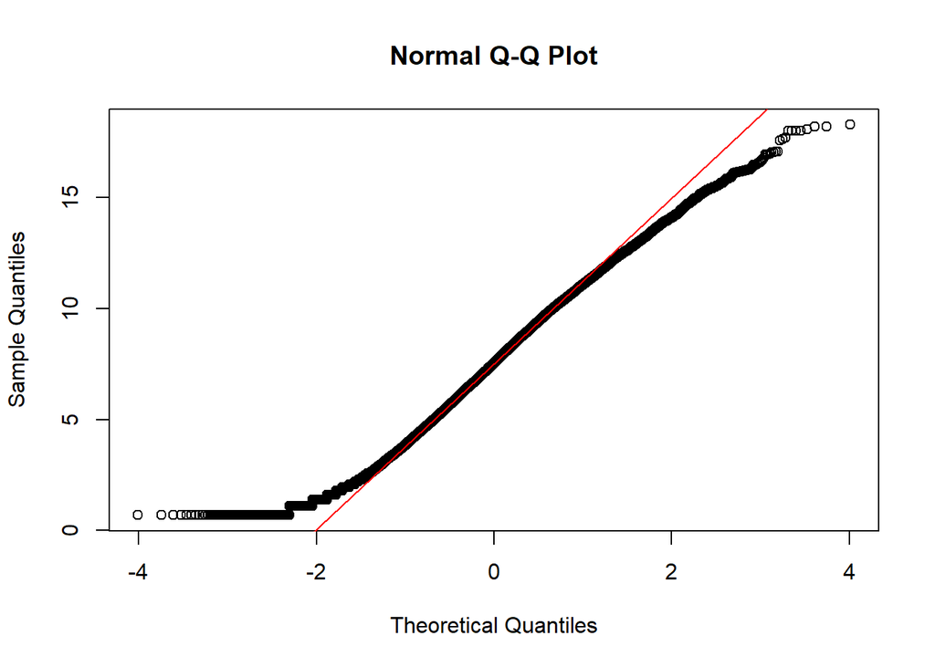

```r
playstore$Reviews_log <- log(playstore$Reviews + 1)
qqnorm(playstore$Reviews_log)
qqline(playstore$Reviews_log, col = "red")
```

```r
#maybe follows a normal distribution

lillie.test(playstore$Reviews)
```

```
##
##  Lilliefors (Kolmogorov-Smirnov) normality test
##
## data:  playstore$Reviews
## D = 0.46062, p-value < 2.2e-16
```

```r
lillie.test(playstore$Reviews_log)
```

```
##
##  Lilliefors (Kolmogorov-Smirnov) normality test
##
## data:  playstore$Reviews_log
## D = 0.024498, p-value < 2.2e-16
```

Q-Q plot which is used to compare the distribution of a dataset against normal distribution. The red line represents what the plot would look like if the playstore$Reviews_log data followed a normal distribution perfectly. In this Q-Q plot, while many points in the middle portion follow the line closely, there’s a noticeable deviation at both ends. The points that significantly deviate from the line, especially in the tails, may suggest outliers or a distribution that is not symmetric.

Since p-value<0.05 ($\alpha=0.05$ significance level) then we Reject the Null Hypothesis. Thus, it does not follow any normal distribution.

```r
ks.test(playstore$Rating, playstore$Reviews) # Reject H0, they don't follow the same distribution
```

```
##
##  Asymptotic two-sample Kolmogorov-Smirnov test
##
## data:  playstore$Rating and playstore$Reviews
## D = 0.95592, p-value < 2.2e-16
## alternative hypothesis: two-sided
```

Since p-value<0.05 ($\alpha=0.05$ significance level) then we Reject the Null Hypothesis. Thus, they do not follow the same distribution.

Price - Rating:

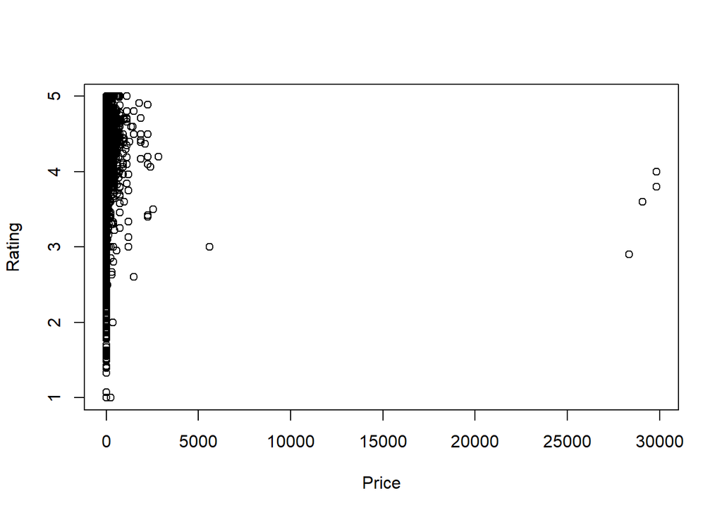

```r
#Price - Rating
playstore$Price <- gsub("[^0-9.]", "", playstore$Price)
playstore$Price <- as.numeric(playstore$Price) #make Price column numeric
plot(playstore$Price + 1, playstore$Rating, xlab ="Price", ylab = "Rating")
```

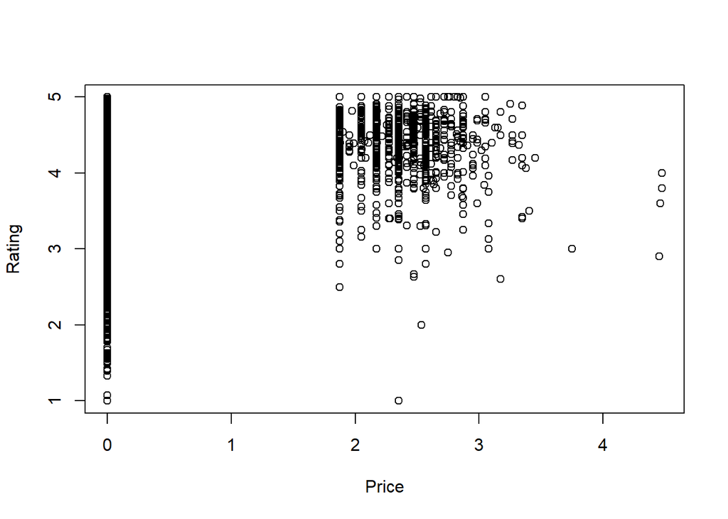

```r
plot(log10(playstore$Price + 1), playstore$Rating, xlab ="Price", ylab = "Rating")
```

#### Content Rating Encoding

Encode the ‘Content_Rating’ column into dummy, a binary indicator, variables.

```r
playstore <- dummy_cols(playstore, select_columns = "Content_Rating",remove_first_dummy = TRUE)
names(playstore)#create dummy variables for each unique value
```

```
##  [1] "Offered_By"                  "Category"
##  [3] "Rating"                      "Reviews"
##  [5] "Size"                        "Price"
##  [7] "Content_Rating"              "Last_Updated_On"
##  [9] "Release_Version"             "OS_Version_Required"
## [11] "Downloads"                   "Major_Version"
## [13] "OS_Version_Numeric"          "newCategory"
## [15] "Cluster"                     "Merged_Category"
## [17] "Class"                       "Reviews_log"
## [19] "Content_Rating_Everyone"     "Content_Rating_Everyone 10+"
## [21] "Content_Rating_Mature 17+"   "Content_Rating_Teen"
## [23] "Content_Rating_Unrated"
```

```r
colnames(playstore) <- gsub(" ", "_", colnames(playstore))
colnames(playstore) <- gsub("\\+", "plus", colnames(playstore))
names(playstore)
```

```
##  [1] "Offered_By"                     "Category"
##  [3] "Rating"                         "Reviews"
##  [5] "Size"                           "Price"
##  [7] "Content_Rating"                 "Last_Updated_On"
##  [9] "Release_Version"                "OS_Version_Required"
## [11] "Downloads"                      "Major_Version"
## [13] "OS_Version_Numeric"             "newCategory"
## [15] "Cluster"                        "Merged_Category"
## [17] "Class"                          "Reviews_log"
## [19] "Content_Rating_Everyone"        "Content_Rating_Everyone_10plus"
## [21] "Content_Rating_Mature_17plus"   "Content_Rating_Teen"
## [23] "Content_Rating_Unrated"
```